# Mini Data Analysis Milestone 2

April Hwang

#load data and tidyverse package

```r
library(datateachr)
library(tidyverse)
```

# Task 1: Process and summarize your data

### 1.1 (1 point): Write research questions from milestone 1

**Research question 1** : What, if any, is the relationship between time and allowance of pet ownership in this dataset? Similarly, is there any relationship between time and availability of accessible parking?

**Research question 2** : Is there a relationship between the number of units and the number of storeys?

**Research question 3** : What are the variables for which information is most readily available (i.e. no missing data) and least readily available (i.e. large amount of missing data)?

**Research question 4** : What are the top three most popular building amenities?

### 1.2 (8 points)

Now, for each of your four research questions, choose one task from options 1-4 (summarizing), and one other task from 4-8 (graphing). You should have 2 tasks done for each research question (8 total). Make sure it makes sense to do them! (e.g. don’t use a numerical variables for a task that needs a categorical variable.). Comment on why each task helps (or doesn’t!) answer the corresponding research question.

Ensure that the output of each operation is printed!

**Summarizing:**

1. Compute the *range*, *mean*, and *two other summary statistics* of **one numerical variable** across the groups of **one categorical variable** from your data.
2. Compute the number of observations for at least one of your categorical variables. Do not use the function `table()`!
3. Create a categorical variable with 3 or more groups from an existing numerical variable. You can use this new variable in the other tasks! *An example: age in years into “child, teen, adult, senior”.*
4. Compute the proportion and counts in each category of one categorical variable across the groups of another categorical variable from your data. Do not use the function `table()`!

**Graphing:**

6. Create a graph of your choosing, make one of the axes logarithmic, and format the axes labels so that they are “pretty” or easier to read.
7. Make a graph where it makes sense to customize the alpha transparency.

Using variables and/or tables you made in one of the “Summarizing” tasks:

8. Create a graph that has at least two geom layers.
9. Create 3 histograms, with each histogram having different sized bins. Pick the “best” one and explain why it is the best.

Make sure it’s clear what research question you are doing each operation for!

**Research question 1** : What, if any, is the relationship between time and allowance of pet ownership in this dataset? Similarly, is there any relationship between time and availability of accessible parking?

*Summarizing*: Create a categorical variable with 3 or more groups from an existing numerical variable.

I will create a new categorical variable (year_level) which identifies the century in which the building was built.

```r
apt_buildings %>%
  mutate(year_level = case_when(year_built < 1901 ~ '19th century',
                                year_built < 2001 ~ '20th century',
                                TRUE ~ '21st century'))
```

```
## # A tibble: 3,455 × 38
##       id air_conditioning amenities             balconies barrier_free_accessi…¹
##    <dbl> <chr>            <chr>                 <chr>     <chr>
##  1 10359 NONE             Outdoor rec faciliti… YES       YES
##  2 10360 NONE             Outdoor pool          YES       NO
##  3 10361 NONE             <NA>                  YES       NO
##  4 10362 NONE             <NA>                  YES       YES
##  5 10363 NONE             <NA>                  NO        NO
##  6 10364 NONE             <NA>                  NO        NO
##  7 10365 NONE             <NA>                  NO        YES
##  8 10366 CENTRAL AIR      Indoor pool , Indoor… YES       NO
##  9 10367 NONE             <NA>                  YES       YES
## 10 10368 NONE             Indoor recreation ro… YES       YES
## # ℹ 3,445 more rows
## # ℹ abbreviated name: ¹barrier_free_accessibilty_entr
## # ℹ 33 more variables: bike_parking <chr>, exterior_fire_escape <chr>,
## #   fire_alarm <chr>, garbage_chutes <chr>, heating_type <chr>, intercom <chr>,
## #   laundry_room <chr>, locker_or_storage_room <chr>, no_of_elevators <dbl>,
## #   parking_type <chr>, pets_allowed <chr>, prop_management_company_name <chr>,
## #   property_type <chr>, rsn <dbl>, separate_gas_meters <chr>, …
```

*Graphing*: Create a graph that has at least two geom layers.

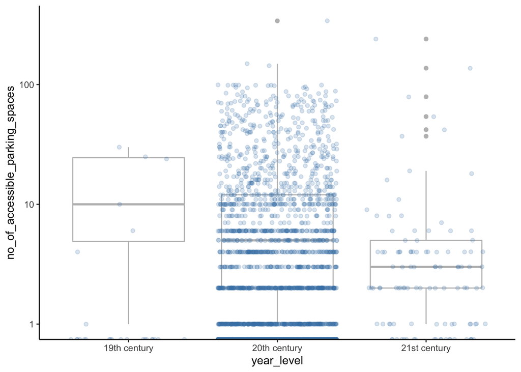

```r
apt_buildings %>%
  mutate(year_level = case_when(year_built < 1901 ~ '19th century',
                                year_built < 2001 ~ '20th century',
                                TRUE ~ '21st century')) %>%
  ggplot(aes(x = year_level, y = no_of_accessible_parking_spaces)) +
  geom_boxplot(colour = 'grey') +
  geom_jitter(alpha = 0.2, colour = 'steelblue') +
  scale_y_log10('no_of_accessible_parking_spaces') +
  theme_classic()
```

**Research question 2** : Is there a relationship between the number of units and the number of storeys?

*Summarizing*: Create a categorical variable with 3 or more groups from an existing numerical variable.

I will create a new categorical variable (*rise_level*) which classifies each building as low-rise, mid-rise or high-rise. For this exercise, low-rise buildings will be defined as buildings with 10 floors or under. Mid-rise buildings are defined as buildings that have between 11 to 15 floors. High-rise buildings are defined as buildings that have 16 floors or above.

```r
apt_buildings %>%
  mutate(rise_level = case_when(no_of_storeys < 11 ~ 'low-rise',
                                no_of_storeys < 16 ~ 'mid-rise',
                                TRUE ~ 'high-rise'))
```

```
## # A tibble: 3,455 × 38
##       id air_conditioning amenities             balconies barrier_free_accessi…¹
##    <dbl> <chr>            <chr>                 <chr>     <chr>
##  1 10359 NONE             Outdoor rec faciliti… YES       YES
##  2 10360 NONE             Outdoor pool          YES       NO
##  3 10361 NONE             <NA>                  YES       NO
##  4 10362 NONE             <NA>                  YES       YES
##  5 10363 NONE             <NA>                  NO        NO
##  6 10364 NONE             <NA>                  NO        NO
##  7 10365 NONE             <NA>                  NO        YES
##  8 10366 CENTRAL AIR      Indoor pool , Indoor… YES       NO
##  9 10367 NONE             <NA>                  YES       YES
## 10 10368 NONE             Indoor recreation ro… YES       YES
## # ℹ 3,445 more rows
## # ℹ abbreviated name: ¹barrier_free_accessibilty_entr
## # ℹ 33 more variables: bike_parking <chr>, exterior_fire_escape <chr>,
## #   fire_alarm <chr>, garbage_chutes <chr>, heating_type <chr>, intercom <chr>,
## #   laundry_room <chr>, locker_or_storage_room <chr>, no_of_elevators <dbl>,
## #   parking_type <chr>, pets_allowed <chr>, prop_management_company_name <chr>,
## #   property_type <chr>, rsn <dbl>, separate_gas_meters <chr>, …
```

*Graphing*:Create a graph that has at least two geom layers.

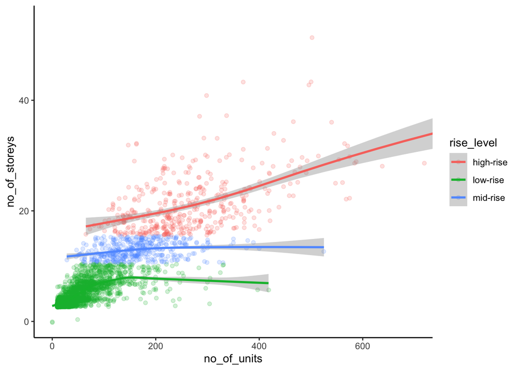

```r
apt_buildings %>%
  mutate(rise_level = case_when(no_of_storeys < 11 ~ 'low-rise',
                                no_of_storeys < 16 ~ 'mid-rise',
                                TRUE ~ 'high-rise')) %>%
  ggplot(aes(x = no_of_units, y = no_of_storeys, colour = rise_level)) +
  geom_jitter(outlier.shape = NA, alpha = 0.2) +
  coord_cartesian(xlim =  c(0, 700)) +
  geom_smooth() +
  theme_classic()
```

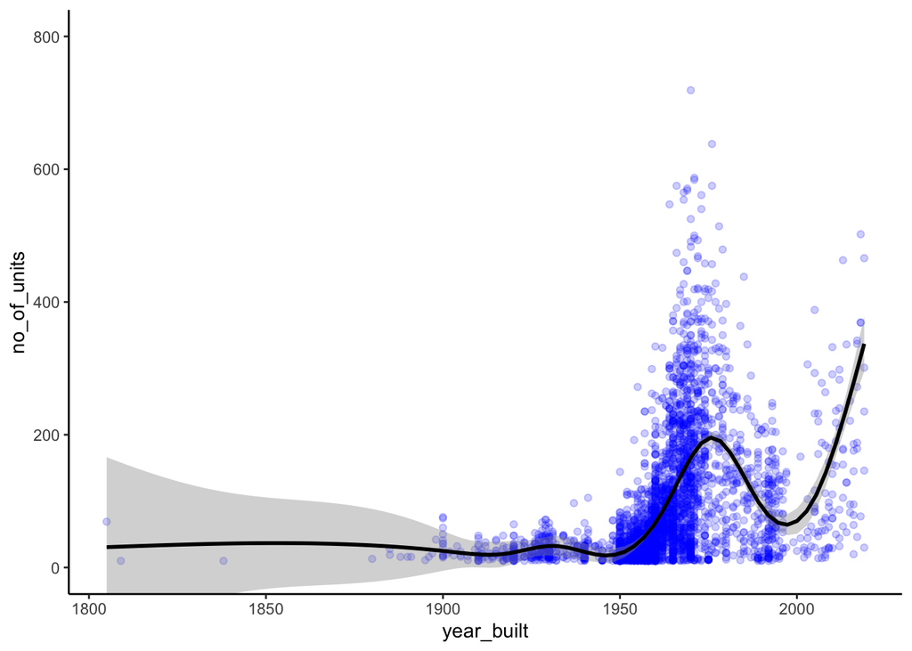

```r
###use for another task
apt_buildings %>%
  ggplot(aes(x = year_built, y = no_of_units)) +
  geom_point(outlier.shape = NA, alpha = 0.2, colour = 'blue') +
  coord_cartesian(ylim =  c(0, 800)) +
  geom_smooth(colour ='black') +
  theme_classic()
```

**Research question 3** : What are the variables for which information is most readily available (i.e. no missing data) and least readily available (i.e. large amount of missing data)?

*Summarizing*: Compute the number of observations for at least one of your categorical variables

For this task, I will compute the NA counts of each level of the all the columns in *apt_buildings*. I will also count the total number of levels as a reference to better answer the reserch question in the future.

```r
#count NA and tidy data
apt_buildings_NA <- apt_buildings %>%
  summarise(across(everything(), ~ sum(is.na(.)))) %>%
  pivot_longer(cols = everything(), names_to = 'col_name', values_to = 'NA_count')

print(apt_buildings_NA)
```

```
## # A tibble: 37 × 2
##    col_name                       NA_count
##    <chr>                             <int>
##  1 id                                    0
##  2 air_conditioning                     85
##  3 amenities                          2518
##  4 balconies                            88
##  5 barrier_free_accessibilty_entr       82
##  6 bike_parking                          0
##  7 exterior_fire_escape                 95
##  8 fire_alarm                           87
##  9 garbage_chutes                       83
## 10 heating_type                         86
## # ℹ 27 more rows
```

```r
#convert apt_building_NA to fct and count levels
as.factor(apt_buildings_NA$col_name) %>%
  nlevels()
```

```
## [1] 37
```

```r
#count NA, tidy data and arrange in descending order
apt_buildings_NA <- apt_buildings %>%
  summarise(across(everything(), ~ sum(is.na(.)))) %>%
  pivot_longer(cols = everything(), names_to = 'col_name', values_to = 'NA_count') %>%
  arrange(desc(NA_count))

print(apt_buildings_NA)
```

```
## # A tibble: 37 × 2
##    col_name                         NA_count
##    <chr>                               <int>
##  1 amenities                            2518
##  2 prop_management_company_name         1363
##  3 parking_type                          350
##  4 no_barrier_free_accessible_units      154
##  5 no_of_accessible_parking_spaces       123
##  6 exterior_fire_escape                   95
##  7 non-smoking_building                   94
##  8 intercom                               90
##  9 pets_allowed                           90
## 10 year_registered                        89
## # ℹ 27 more rows
```

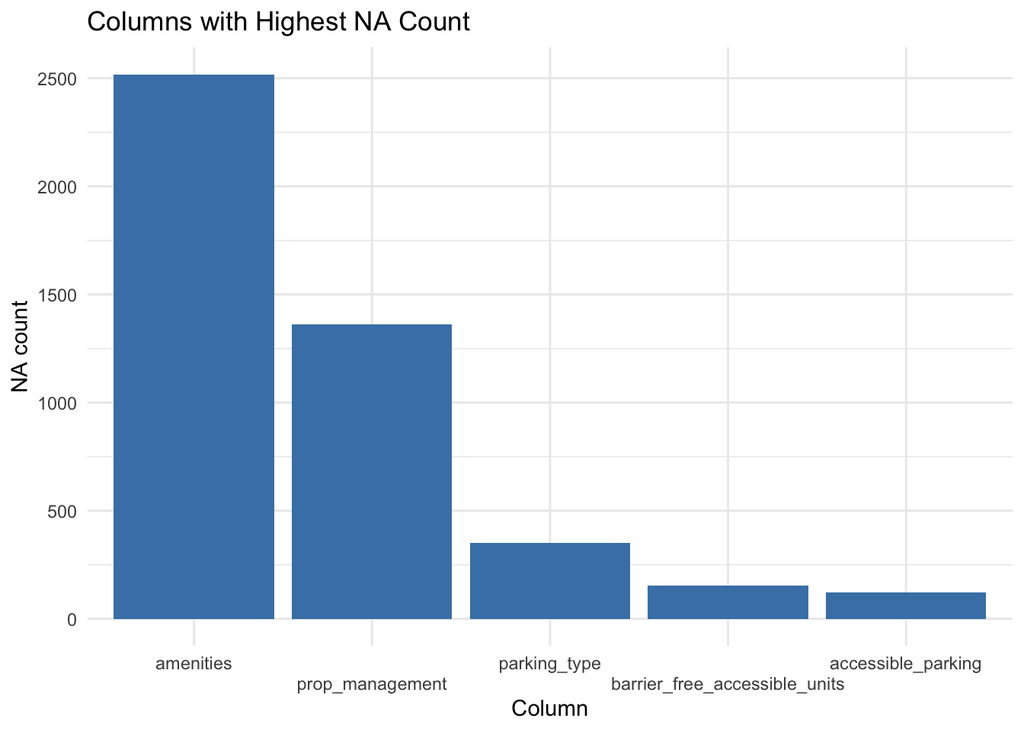

```r
#create bar graph for 5 columns with the highest number of NA values
apt_buildings_NA %>%
  slice_max(NA_count, n = 5) %>%

  #shorten column names to fit graph
  mutate(col_name = fct_recode(col_name,
                               'prop_management' = 'prop_management_company_name',
                               'accessible_parking' = 'no_of_accessible_parking_spaces',
                               'barrier_free_accessible_units' = 'no_barrier_free_accessible_units')) %>%

  #plot point graph in descending order
  ggplot(aes(x = fct_rev(fct_reorder(col_name, NA_count)), y = NA_count)) +
  geom_col(fill = 'steelblue') +
  scale_x_discrete(guide = guide_axis(n.dodge=2)) +
  ggtitle('Columns with Highest NA Count') +
  xlab('Column') +
  ylab('NA count') +
  theme_minimal()
```

**Research question 4** : What are the top three most popular building amenities?

*Summary* Compute the number of observations for at least one of your categorical variables.

```r
#convert amenities to factor
amenities_fct <- as.factor(apt_buildings$amenities)

#compute counts of each level
amenities_count <- fct_count(amenities_fct)

#convert each cell into single value
amenities_count %>%
  separate(f, into = c('f1','f2','f3', 'f4','f5','f6'), sep = ' , ') %>% #convert each cell to single value
  pivot_longer(c('f1','f2','f3', 'f4','f5','f6'), names_to = 'f', values_to = 'amenities_type') %>% #place amenities in single variable
  select(amenities_type) %>% #show only amenities type
  na.omit() %>% #omit NA
  count(amenities_type) #count each amenity type
```

```
## # A tibble: 7 × 2
##   amenities_type             n
##   <chr>                  <int>
## 1 Child play area           26
## 2 Indoor exercise room      36
## 3 Indoor pool               21
## 4 Indoor recreation room    36
## 5 Outdoor pool              26
## 6 Outdoor rec facilities    31
## 7 Sauna                     31
```

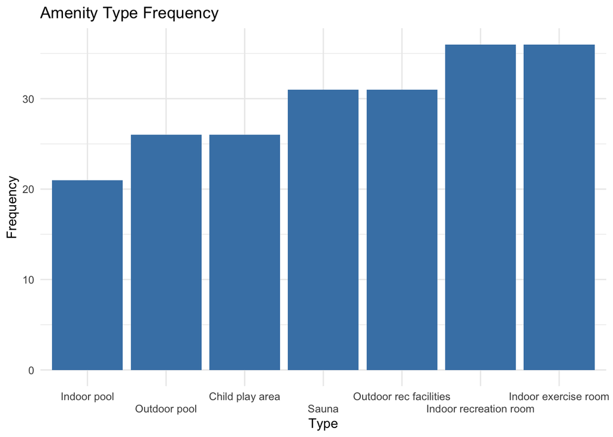

```r
#convert amenities to factor
amenities_fct <- as.factor(apt_buildings$amenities)

#compute counts of each level
amenities_count <- fct_count(amenities_fct)

#convert each cell into single value
amenities_count %>%
  separate(f, into = c('f1','f2','f3', 'f4','f5','f6'), sep = ' , ') %>% #convert each cell to single value
  pivot_longer(c('f1','f2','f3', 'f4','f5','f6'), names_to = 'f', values_to = 'amenities_type') %>% #place amenities in single variable
  select(amenities_type) %>% #show only amenities type
  na.omit() %>% #omit NA

  #create bar graph in ascending order
  ggplot(aes(x = fct_rev(fct_infreq(amenities_type)))) +
  geom_bar(fill = 'steelblue', width = 0.9) +
  scale_x_discrete(guide = guide_axis(n.dodge=2)) +
  ggtitle('Amenity Type Frequency') +
  xlab('Type') +
  ylab('Frequency') +
  theme_minimal()
```

### 1.3 (2 points)

Based on the operations that you’ve completed, how much closer are you to answering your research questions? Think about what aspects of your research questions remain unclear. Can your research questions be refined, now that you’ve investigated your data a bit more? Which research questions are yielding interesting results?

# Task 2: Tidy your data

In this task, we will do several exercises to reshape our data. The goal here is to understand how to do this reshaping with the `tidyr` package.

A reminder of the definition of *tidy* data:

- Each row is an **observation**
- Each column is a **variable**
- Each cell is a **value**

### 2.1 (2 points)

Based on the definition above, can you identify if your data is tidy or untidy? Go through all your columns, or if you have >8 variables, just pick 8, and explain whether the data is untidy or tidy.

*apt_building* is untidy for the following reasons: - *amenities* contains multiple measurements - *bike_parking* contains multiple measurements - *parking_type* contains multiple measurements - *facilities_available* contains multiple measurements

### 2.2 (4 points)

Now, if your data is tidy, untidy it! Then, tidy it back to it’s original state.

If your data is untidy, then tidy it! Then, untidy it back to it’s original state.

Be sure to explain your reasoning for this task. Show us the “before” and “after”.

Before (untidy):

```r
apt_buildings_fct <- apt_buildings %>% mutate(across(where(is_character),as_factor)) #convert chr to fct

levels(apt_buildings_fct$facilities_available)
```

```
## [1] "Recycling bins"       "Green Bin / Organics" "Unknown"
## [4] "Not Available"
```

After (tidy then untidy):

```r
apt_buildings_fct <- apt_buildings %>% mutate(across(where(is_character),as_factor)) #convert chr to fct

#levels(apt_buildings_fct$facilities_available) #check for types of facilities

#tidy facilities_available
apt_buildings_tidy <- apt_buildings_fct %>%
    mutate(facilities_available = fct_recode(facilities_available,
                                           'Compost' = 'Green Bin / Organics',
                                           'NA' = 'Unknown',
                                           'NA' = 'Not Available'))

#check that data is tidy
print(select(apt_buildings_tidy,facilities_available))
```

```
## # A tibble: 3,455 × 1
##    facilities_available
##    <fct>
##  1 Recycling bins
##  2 Compost
##  3 Compost
##  4 Compost
##  5 Compost
##  6 Compost
##  7 NA
##  8 Compost
##  9 Recycling bins
## 10 Recycling bins
## # ℹ 3,445 more rows
```

```r
#untidy facilities_available

apt_buildings_untidy <- apt_buildings_fct %>%
    mutate(facilities_available = fct_recode(facilities_available,
                                           'Green Bin / Organics' = 'Compost',
                                           'Unknown' = 'NA',
                                           'Not Available' = 'NA'))
#check that data is tidy
print(select(apt_buildings_untidy,facilities_available))
```

```
## # A tibble: 3,455 × 1
##    facilities_available
##    <fct>
##  1 Recycling bins
##  2 Green Bin / Organics
##  3 Green Bin / Organics
##  4 Green Bin / Organics
##  5 Green Bin / Organics
##  6 Green Bin / Organics
##  7 Unknown
##  8 Green Bin / Organics
##  9 Recycling bins
## 10 Recycling bins
## # ℹ 3,445 more rows
```

### 2.3 (4 points)

Now, you should be more familiar with your data, and also have made progress in answering your research questions. Based on your interest, and your analyses, pick 2 of the 4 research questions to continue your analysis in the remaining tasks:

1. What are the variables for which information is most readily available (i.e. no missing data) and least readily available (i.e. large amount of missing data)?
2. Is there a relationship between the number of units and the number of storeys?

Explain your decision for choosing the above two research questions.

Now, try to choose a version of your data that you think will be appropriate to answer these 2 questions. Use between 4 and 8 functions that we’ve covered so far (i.e. by filtering, cleaning, tidy’ing, dropping irrelevant columns, etc.).

(If it makes more sense, then you can make/pick two versions of your data, one for each research question.)

# Task 3: Modelling

## 3.0 (no points)

Pick a research question from 1.2, and pick a variable of interest (we’ll call it “Y”) that’s relevant to the research question. Indicate these.

**Research Question**: Is there a relationship between the number of units and the number of storeys?

**Variable of interest**: Number of units

## 3.1 (3 points)

Fit a model or run a hypothesis test that provides insight on this variable with respect to the research question. Store the model object as a variable, and print its output to screen. We’ll omit having to justify your choice, because we don’t expect you to know about model specifics in STAT 545.

```r
#prep data using 4-8 functions
apt_buildings_unit_storeys <- apt_buildings %>%

  #use select() to drop irrelevant columns
  select(no_of_storeys, no_of_units) %>%

  #use arrange() to reorder rows
  relocate(no_of_units) %>%

  #use desc() to sort rows in descending order
  arrange(desc(no_of_units)) %>%

  #use rename() to shorten column labels
  rename(storeys = no_of_storeys,
         units = no_of_units) %>%

  #use slice() to remove first outlier row with 4000+ units
  slice(-1)

print(apt_buildings_unit_storeys)
```

```
## # A tibble: 3,454 × 2
##    units storeys
##    <dbl>   <dbl>
##  1   719      29
##  2   638      28
##  3   587      29
##  4   584      29
##  5   575      22
##  6   575      30
##  7   571      32
##  8   568      22
##  9   565      32
## 10   561      25
## # ℹ 3,444 more rows
```

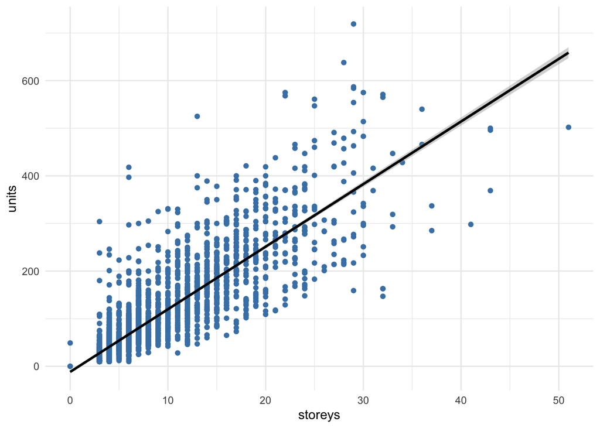

```r
#linear regression modeling

apt_buildings_unit_storeys %>%
  ggplot(aes(x = storeys, y = units)) +
    geom_point(colour = 'steelblue') +
    geom_smooth(method = 'lm', colour = 'black') +
    theme_minimal()
```

## 3.2 (3 points)

Produce something relevant from your fitted model: either predictions on Y, or a single value like a regression coefficient or a p-value.

- Be sure to indicate in writing what you chose to produce.
- Your code should either output a tibble (in which case you should indicate the column that contains the thing you’re looking for), or the thing you’re looking for itself.
- Obtain your results using the `broom` package if possible. If your model is not compatible with the broom function you’re needing, then you can obtain your results by some other means, but first indicate which broom function is not compatible.

# Task 4: Reading and writing data

Get set up for this exercise by making a folder called `output` in the top level of your project folder / repository. You’ll be saving things there.

## 4.1 (3 points)

Take a summary table that you made from Task 1, and write it as a csv file in your `output` folder. Use the `here::here()` function.

- **Robustness criteria**: You should be able to move your Mini Project repository / project folder to some other location on your computer, or move this very Rmd file to another location within your project repository / folder, and your code should still work.
- **Reproducibility criteria**: You should be able to delete the csv file, and remake it simply by knitting this Rmd file.

## 4.2 (3 points)

Write your model object from Task 3 to an R binary file (an RDS), and load it again. Be sure to save the binary file in your `output` folder. Use the functions `saveRDS()` and `readRDS()`.

- The same robustness and reproducibility criteria as in 4.1 apply here.

# Overall Reproducibility/Cleanliness/Coherence Checklist

Here are the criteria we’re looking for.

## Coherence (0.5 points)

The document should read sensibly from top to bottom, with no major continuity errors.

The README file should still satisfy the criteria from the last milestone, i.e. it has been updated to match the changes to the repository made in this milestone.

## File and folder structure (1 points)

You should have at least three folders in the top level of your repository: one for each milestone, and one output folder. If there are any other folders, these are explained in the main README.

Each milestone document is contained in its respective folder, and nowhere else.

Every level-1 folder (that is, the ones stored in the top level, like “Milestone1” and “output”) has a `README` file, explaining in a sentence or two what is in the folder, in plain language (it’s enough to say something like “This folder contains the source for Milestone 1”).

## Output (1 point)

All output is recent and relevant:

- All Rmd files have been `knit`ted to their output md files.
- All knitted md files are viewable without errors on Github. Examples of errors: Missing plots, “Sorry about that, but we can’t show files that are this big right now” messages, error messages from broken R code
- All of these output files are up-to-date – that is, they haven’t fallen behind after the source (Rmd) files have been updated.
- There should be no relic output files. For example, if you were knitting an Rmd to html, but then changed the output to be only a markdown file, then the html file is a relic and should be deleted.

Our recommendation: delete all output files, and re-knit each milestone’s Rmd file, so that everything is up to date and relevant.

## Tagged release (0.5 point)

You’ve tagged a release for Milestone 2.

### Attribution

Thanks to Victor Yuan for mostly putting this together.